# Counting Palm Tree from Satellite image

This is an attempt to count palm tree from satellite image. Few palm tree image will be use as samples, match it to a palm tree farm satellite image, then capture & count palm trees in the farm.

### Import library & images

```python
import numpy as np
from PIL import Image
import matplotlib.pyplot as plt
from pylab import *
%matplotlib inline

imageTotal = np.asarray(Image.open('palm_tree_full.png'))
image1 = np.asarray(Image.open('palm_tree_1.png'))
image2 = np.asarray(Image.open('palm_tree_2.png'))
image3 = np.asarray(Image.open('palm_tree_3.png'))
image4 = np.asarray(Image.open('palm_tree_4.png'))
image5 = np.asarray(Image.open('palm_tree_5.png'))
image6 = np.asarray(Image.open('palm_tree_6.png'))
```

### Display sample palm tree image

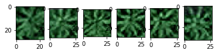

```python
ax1 = plt.subplot(1,6,1)
ax2 = plt.subplot(1,6,2)
ax3 = plt.subplot(1,6,3)
ax4 = plt.subplot(1,6,4)
ax5 = plt.subplot(1,6,5)
ax6 = plt.subplot(1,6,6)

ax1.imshow(image1);
ax2.imshow(image2);
ax3.imshow(image3);
ax4.imshow(image4);
ax5.imshow(image5);
ax6.imshow(image6);



# plt.axis('off');
```

### Display full image of palm tree farm

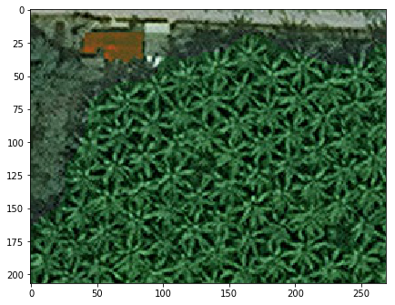

```python
figure(figsize = (7,7))
imshow(imageTotal);
```

### Pre-process image

```python
full_img = imageTotal[:,:,1]
sample_1 = image1[:,:,1]
sample_2 = image2[:,:,1]
sample_3 = image3[:,:,1]
sample_4 = image4[:,:,1]
sample_5 = image5[:,:,1]
sample_6 = image6[:,:,1]
```

### Match template with scikit-image

Sample image will be match with full image using normalized correlation.

```python
from skimage.feature import match_template

result_1 = match_template(full_img, sample_1)
result_2 = match_template(full_img, sample_2)
result_3 = match_template(full_img, sample_3)
result_4 = match_template(full_img, sample_4)
result_5 = match_template(full_img, sample_5)
result_6 = match_template(full_img, sample_6)
```

### Filter high correlation result to get data point

#### Challenges:

With low pixel image download from Google search. Correlation thresholds set after trial and error test. Because of low pixel image, correlation thresholds need to be lower, enabling capture more data point. However, a low correlation threshold may cause wrong data point captured.

```python
filter_result_1 = np.where(result_1>0.35)
filter_result_2 = np.where(result_2>0.35)
filter_result_3 = np.where(result_3>0.30)
filter_result_4 = np.where(result_4>0.30)
filter_result_5 = np.where(result_5>0.30)
filter_result_6 = np.where(result_6>0.30)
```

### Number of data point captured after matching each sample

```python
print('filter_result_1 =',shape(filter_result_1)[1])
print('filter_result_2 =',shape(filter_result_2)[1])
print('filter_result_3 =',shape(filter_result_3)[1])
print('filter_result_4 =',shape(filter_result_4)[1])
print('filter_result_5 =',shape(filter_result_5)[1])
print('filter_result_6 =',shape(filter_result_6)[1])
```

```
filter_result_1 = 55
filter_result_2 = 43
filter_result_3 = 33
filter_result_4 = 117
filter_result_5 = 74
filter_result_6 = 111
```

### Compiling all matches samples

result are now with data point from all samples.

```python
result = np.concatenate((filter_result_1,filter_result_2,filter_result_3
                         ,filter_result_4,filter_result_5,filter_result_6),axis=1)
result = np.swapaxes(result,0,1)
result = result[result[:, 0].argsort()]
result = np.swapaxes(result,0,1)
```

```python
print('Total data point collected =', len(result[0]))
```

```
Total data point collected = 433
```

### Clean up duplicate data point

Data point are captured from multiple samples, same data point may captured multiple time, which can cause duplicate. Clean up is needed. When multiple data point captured is too near in range, we can ignore it. Only capture the first data point.

```python
n = 0
m = 0
captured = ([],[])
for i in range(len(result[0])):
    this = result[0][i]
    if this not in range(m,n):
        captured[0].append(result[0][i])
        captured[1].append(result[1][i])
        m = this
        n = this + 4
captured =(np.asarray(captured[0]),np.asarray(captured[1]))
```

### Data point captured

```python
captured
```

```
(array([ 20,  26,  30,  34,  39,  45,  49,  53,  57,  63,  67,  71,  75,
         79,  83,  87,  91,  95, 101, 105, 109, 113, 117, 122, 126, 130,
        134, 138, 142, 146, 150, 154, 159, 164, 168, 172, 176], dtype=int64),
 array([152, 134, 127, 236, 234,  85, 149, 193, 166, 102,  98, 145,  82,
        184, 119, 226, 206, 139, 183,  53,  28,  30, 203,  72, 180,  45,
        221,  26, 130,  65, 239, 170, 151, 199, 191, 237, 108], dtype=int64))
```

### Counting Palm Tree

```python
print('Number of palm tree in the farm =', len(captured[0]))
```

```
Number of palm tree in the farm = 37
```

### Palm Trees captured in Palm Tree Farm satellite image

As visualization shows, with low pixel image, is hard to capture all palm trees. There's also a few duplicate count even after data cleaning. Therefore number of palm tree count is inaccurate. However, we can expect to have higher accuracy with high pixel image.

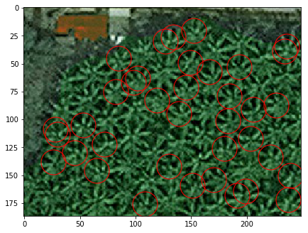

```python
figure(figsize = (7,7))
for punto in range(shape(captured)[1]):
    plot(captured[1][punto],captured[0][punto], 'o',
        markeredgecolor='r', markerfacecolor='none', markersize=35)

imshow(imageTotal[10:-10,10:-10,:]);
```